# Out-of-Class 2

Daniel Truver

11/13/2018

Wednesdays are relatively free. I have no classes. There is never homework due. It is not a weekend, so my friend(s) have class or work. Therefore, I am left to my own devices for most of the day. Sometimes this leads to a large bump in productivity. Other times it leads to regret. But most importantly, it’s a day where I can choose what I want to do and when to do it.

So, I created a time series for this Wednesday. It documents, in rough terms, what activities I did (`activity` variable), when I did them (`when` variable), and how they affected my mood (`will_to_live` variable). While depressing to create, it did give me some insight on how to spend my free time. A plot of the data is below.

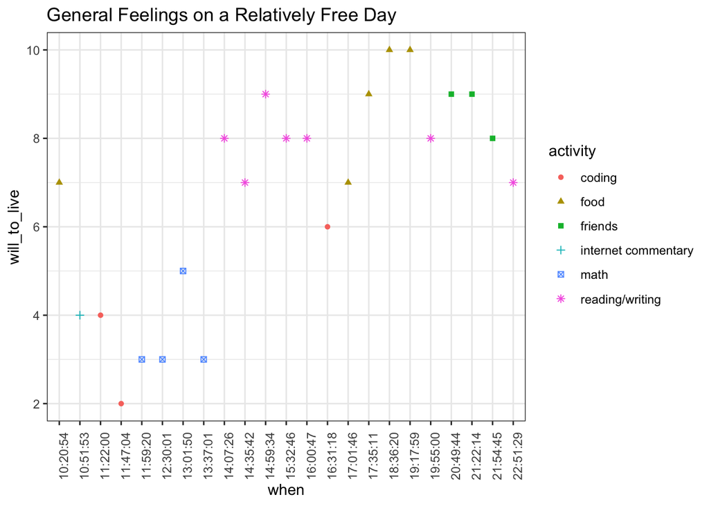

As you can see, the areas of most suffering are those in which I have staked my career: coding and math. The areas of high life expectancy are reading, writing, and anything to do with food. Friends are also up there, but friends ultimately die or ask you for money, so they’re not a sustainable source of happiness.

I also tracked the variable `weather` since I thought perhaps that would have an influence on my demeanor. It did not because the only observed value was `rain`. All we can conclude from this is that rain may shift all values up or down by a constant.

On the data collection, I did it in `R` using this code block and a timer that reminded me to record throughout the day.

```r
load("mydata.rdata")
when = date()
will_to_live = 7
activity = "reading"
weather = "rain"
newrow = c(when, will_to_live, activity, weather)
newdata = rbind(newdata, newrow)
save(newdata,file = "mydata.rdata")
```